# iNaturalist

Shale

2/14/2022

# Data Setup

```r
librarian::shelf(
  digest, dplyr, DT, glue, purrr, readr, stringr, tidyr, here, keras, tensorflow, reticulate)
```

[output not shown]

```r
# path to folder containing species directories of images
dir_src  <- "/courses/EDS232/inaturalist-2021/train_mini"
dir_dest <- "~/inat"
dir.create(dir_dest, showWarnings = F)

# get list of directories, one per species (n = 10,000 species)
dirs_spp <- list.dirs(dir_src, recursive = F, full.names = T)
n_spp <- length(dirs_spp)

# set seed (for reproducible results)
# just before sampling (otherwise get different results)
# based on your username (unique amongst class)
Sys.info()[["user"]] %>%
  digest::digest2int() %>%
  set.seed()
i10 <- sample(1:n_spp, 10)

# show the 10 indices sampled of the 10,000 possible
i10
```

```
##  [1] 4004 6713   77 6561 5576 6900 6332 8064 7914 5442
```

```r
# show the 10 species directory names
basename(dirs_spp)[i10]
```

```
##  [1] "04003_Animalia_Chordata_Aves_Passeriformes_Nectariniidae_Anthobaphes_violacea"
##  [2] "06712_Plantae_Tracheophyta_Magnoliopsida_Asterales_Asteraceae_Cirsium_oleraceum"
##  [3] "00076_Animalia_Arthropoda_Arachnida_Araneae_Salticidae_Colonus_sylvanus"
##  [4] "06560_Plantae_Tracheophyta_Magnoliopsida_Apiales_Araliaceae_Oplopanax_horridus"
##  [5] "05575_Fungi_Basidiomycota_Agaricomycetes_Agaricales_Strophariaceae_Agrocybe_pediades"
##  [6] "06899_Plantae_Tracheophyta_Magnoliopsida_Asterales_Asteraceae_Monoptilon_bellioides"
##  [7] "06331_Plantae_Tracheophyta_Liliopsida_Poales_Poaceae_Austroderia_richardii"
##  [8] "08063_Plantae_Tracheophyta_Magnoliopsida_Fabales_Fabaceae_Senna_covesii"
##  [9] "07913_Plantae_Tracheophyta_Magnoliopsida_Fabales_Fabaceae_Astragalus_danicus"
## [10] "05441_Fungi_Ascomycota_Lecanoromycetes_Teloschistales_Teloschistaceae_Teloschistes_flavicans"
```

```r
i2 <- i10[1:2]
basename(dirs_spp)[i2]
```

```
## [1] "04003_Animalia_Chordata_Aves_Passeriformes_Nectariniidae_Anthobaphes_violacea"
## [2] "06712_Plantae_Tracheophyta_Magnoliopsida_Asterales_Asteraceae_Cirsium_oleraceum"
```

```r
# setup data frame with source (src) and destination (dest) paths to images
idata <- tibble(
  set     = c(rep("spp2", 2), rep("spp10", 10)),
  dir_sp  = c(dirs_spp[i2], dirs_spp[i10]),
  tbl_img = map(dir_sp, function(dir_sp){
    tibble(
      src_img = list.files(dir_sp, full.names = T),
      subset  = c(rep("train", 30), rep("validation", 10), rep("test", 10))) })) %>%
  unnest(tbl_img) %>%
  mutate(
    sp       = basename(dir_sp),
    img      = basename(src_img),
    dest_img = glue("{dir_dest}/{set}/{subset}/{sp}/{img}"))

# show source and destination for first 10 rows of tibble
# idata %>%
#   select(src_img, dest_img)

idata %>%
  pwalk(function(src_img, dest_img, ...){
    dir.create(dirname(dest_img), recursive = T, showWarnings = F)
    file.copy(src_img, dest_img) })
```

Tried a thing:

```r
# filepath labels
train2_dir = file.path(dir_dest, "spp2/train")
test2_dir = file.path(dir_dest, "spp2/test")
validation2_dir = file.path(dir_dest, "spp2/validation")
train10_dir = file.path(dir_dest, "spp10/train")
test10_dir = file.path(dir_dest, "spp10/test")
validation10_dir = file.path(dir_dest, "spp10/validation")

# Resize images for binary classification
datagen_resizr <- image_data_generator(rescale = 1/255)

tensor_gen <- function(img_subset) {

  img_dir2 = paste0(img_subset + "2_dir")
  img_dir10 = paste0(img_subset + "10_dir")

    flow_images_from_directory(
  img_dir2,
  datagen_resizr,
  target_size = c(150, 150),
  batch_size = 10,
  class_mode = "binary"
  )

    generator10 <- flow_images_from_directory(
  img_dir10,
  datagen_resizr,
  target_size = c(150, 150),
  batch_size = 10,
  class_mode = "binary"
  )
}
```

Manually:

```r
# filepath labels
train_dir = here("inat/spp2/train")
test_dir = here("inat/spp2/test")
validation_dir = here("inat/spp2/validation")
train10_dir = here("inat/spp10/train")
test10_dir = here("inat/spp10/test")
validation10_dir = here("inat/spp10/validation")

# Resize images for binary classification
datagen <- image_data_generator(rescale = 1/255)
```

```
## Loaded Tensorflow version 2.7.1
```

```r
# Avoid overfitting
train_datagen <- image_data_generator(
  rescale = 1/255,
  rotation_range = 40,
  width_shift_range = 0.2,
  height_shift_range = 0.2,
  shear_range = 0.2,
  zoom_range = 0.2,
  horizontal_flip = TRUE,
  fill_mode = "nearest"
)

train_generator <- flow_images_from_directory(
  train_dir,
  train_datagen,
  target_size = c(150, 150),
  batch_size = 30,
  class_mode = "binary"
)

test_generator <- flow_images_from_directory(
  test_dir,
  datagen,
  target_size = c(150, 150),
  batch_size = 10,
  class_mode = "binary"
)

val_generator <- flow_images_from_directory(
  validation_dir,
  datagen,
  target_size = c(150, 150),
  batch_size = 10,
  class_mode = "binary"
)
```

# Binary Neural Net

```r
nn_model <- keras_model_sequential() %>%
  layer_dense(units = 16, activation = "relu", input_shape = c(150,150,3)) %>%
  layer_dense(units = 16, activation = "relu") %>%
  layer_flatten() %>%
  layer_dense(units =  1, activation = "sigmoid")
```

```r
nn_model %>% compile(
  optimizer = "rmsprop",
  loss      = "binary_crossentropy",
  metrics   = c("accuracy"))
```

```r
nn_history <- nn_model %>% fit(
  train_generator,
  steps_per_epoch = 1,
  epochs = 20,
  validation_data = val_generator,
  validation_steps = 1,
  verbose = 1
)
```

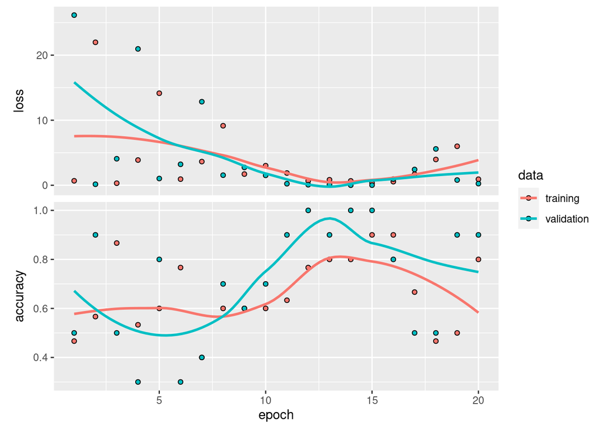

```r
plot(nn_history)
```

```r
# nn_model %>% predict(test_generator)

nn_model %>% evaluate(test_generator, steps = 10)
```

```
##      loss  accuracy
## 0.2769409 0.9000000
```

# Binary Convolutional Neural Net

```r
conv_model <- keras_model_sequential() %>%
layer_conv_2d(filters = 32, kernel_size = c(3, 3), activation = "relu",
input_shape = c(150, 150, 3)) %>%
layer_max_pooling_2d(pool_size = c(2, 2)) %>%
layer_conv_2d(filters = 64, kernel_size = c(3, 3), activation = "relu") %>% layer_max_pooling_2d(pool_size = c(2, 2)) %>%
layer_conv_2d(filters = 128, kernel_size = c(3, 3), activation = "relu") %>% layer_max_pooling_2d(pool_size = c(2, 2)) %>%
layer_conv_2d(filters = 128, kernel_size = c(3, 3), activation = "relu") %>% layer_max_pooling_2d(pool_size = c(2, 2)) %>%
layer_flatten() %>%
layer_dense(units = 512, activation = "relu") %>%
layer_dense(units = 1, activation = "sigmoid")
```

```r
conv_model %>% compile(
  loss = "binary_crossentropy",
  optimizer = "rmsprop",
  metrics = c("acc")
)
```

```r
c_history <- conv_model %>% fit(
  train_generator,
  steps_per_epoch = 2,
  epochs = 20,
  validation_data = val_generator,
  validation_steps = 2
)
```

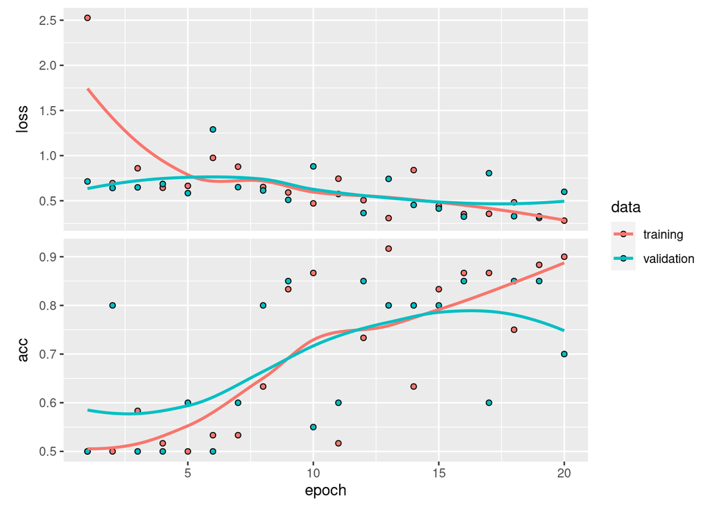

```r
plot(c_history)
```

```r
# conv_model %>% predict(test_generator)

conv_model %>% evaluate(test_generator, steps = 10)
```

```
##      loss       acc
## 0.3749525 0.8500000
```

## Comparison of NN/CNN for Binary Classification:

**For the binary classification problem, I found that the standard neural net and convolutional neural net typically performed quite similarly on the testing data, with loss values around 0.3-0.5 and accuracy usually between 80-90%. Because the models learn slightly differently each time, the exact numbers vary. They are both calculated after 20 epochs (reduced from 30 to save on processing time because accuracy was not any higher with 30 vs 20 epochs).**

# Multiclass Neural Net

```r
train10_generator <- flow_images_from_directory(
  train10_dir,
  train_datagen,
  target_size = c(150, 150),
  batch_size = 20,
  class_mode = "categorical"
)

test10_generator <- flow_images_from_directory(
  test10_dir,
  datagen,
  target_size = c(150, 150),
  batch_size = 10,
  class_mode = "categorical"
)

val10_generator <- flow_images_from_directory(
  validation10_dir,
  datagen,
  target_size = c(150, 150),
  batch_size = 10,
  class_mode = "categorical"
)
```

```r
model10 <- keras_model_sequential() %>%
  layer_dense(units = 64, activation = "relu", input_shape = c(150,150,3)) %>%
  layer_dense(units = 64, activation = "relu") %>%
  layer_flatten() %>%
  layer_dense(units = 64, activation = "relu") %>%
  layer_dense(units = 10, activation = "softmax")
```

```r
model10 %>% compile(
  optimizer = "rmsprop",
  loss = "categorical_crossentropy",
  metrics = c("acc")
)
```

```r
history10 <- fit(model10,
  train10_generator,
  steps_per_epoch = 10,
  epochs = 20,
  validation_data = val10_generator,
  validation_steps = 10
)
```

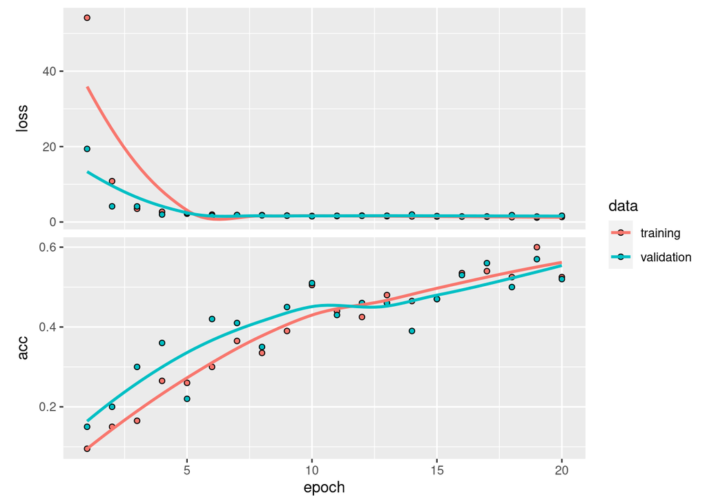

```r
plot(history10)
```

```r
# model10 %>% predict(test10_generator) %>% DT::datatable(options = list(pageLength = 20))

model10 %>% evaluate(test10_generator, steps = 100)
```

```
##     loss      acc
## 1.566274 0.530000
```

```r
loss_50e = 2.25
acc_50e = .52
```